# Paper Presentation

APEC 8990: Environment and Development Economics

Matt Braaksma

University of Minnesota

September 5, 2024

## Motivation

- Poverty eradication and global warming are enormous challenges facing the global community
  - Issues are inter-linked
- Climate change is known to hinder poverty eradication efforts
  - But how does poverty eradication impact the environment?

## Poverty alleviation and local environmental degradation: An empirical analysis in Colombia

### Daniele Malerba

- Explores the causal link between poverty reduction at the household level and environmental impact at the local (municipal) level
- Cash transfer program in Colombia increases consumption at the household level
- Unexpectedly, this does not increase deforestation in the municipality

## Background

- *Familias en Acción* (FA) in Colombia
  - conditional cash transfer program
- Eligibility determined in a two step process
  1. Target municipalities<sup>1</sup>
  2. Target households<sup>2</sup>
     - Included health, nutrition and education stipulations to remain eligible
[^1]: Criteria: provision of appropriate documentation, the presence of at least one bank, the presence of facilities able to provide access to basic education and healthcare, and a population size of <100,000 inhabitants
[^2]: Criteria: poorest 20% of families with children between 0 and 17 years of age, and required to register and to comply with the conditions of the program

## Data

### Household data

- FA program evaluation
  - Three waves: 2002, 2003 and 2005/6

### Municipal Data

- Institute of Hydrology, Meteorology and Environmental Studies 30m Forest Cover
  - 2000, 2005
- Open-Data Inventory for Anthropogenic CO<sub>2</sub> 1km monthly emissions
  - 2000, 2005

## Empirical Strategy

### Household effects

$$\delta Y_i = \alpha + \delta * T_i + X_i + \epsilon_i$$

where $\delta Y_i$ represents the difference in outcome between the two periods, and $X_i$ are baseline variables used for regression adjustment. The coefficient d represents the DID estimate.

- Outcome variable: number of weekly days of beef/milk consumption, refrigerator ownership
- Uses inverse probability treatment weighting and sampling weights

### Municipal effects

$$y_{it} = \beta_0 + \beta_1 *Treat_i + \beta_2 * Post_t + \beta_3 * (Treat_i * Post_t) + \beta_4 X_{it} + \epsilon_{it}$$

where $y_{it}$ is the outcome of interest, such as deforestation in municipality $i$ in year $t$; $Treat_i$ is equal to 1 if the municipality enrolled by 2004 and 0 otherwise; $Post_t$ is equal to 1 for the period after treatment (in this case 2005), and zero for 2000.

- municipality and year fixed effects

## Results

### Household Level

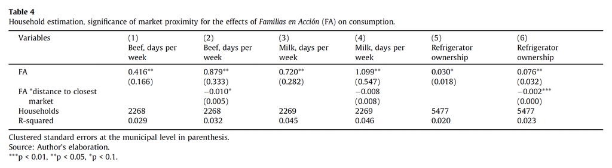

- FA has a positive and significant effect:
  - Beef consumption
  - Milk consumption
  - Refrigerator ownership
- Interaction effect with market distance is negative and significant:
  - Refrigerator ownership

## Results

### Municipal Level

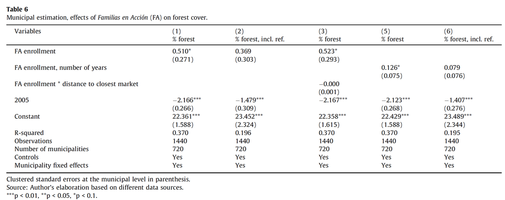

- Municipalities enrolled in FA:
  - Less deforestation
  - Statistically insignificant when reforestation is included

## Results

### Municipal Level

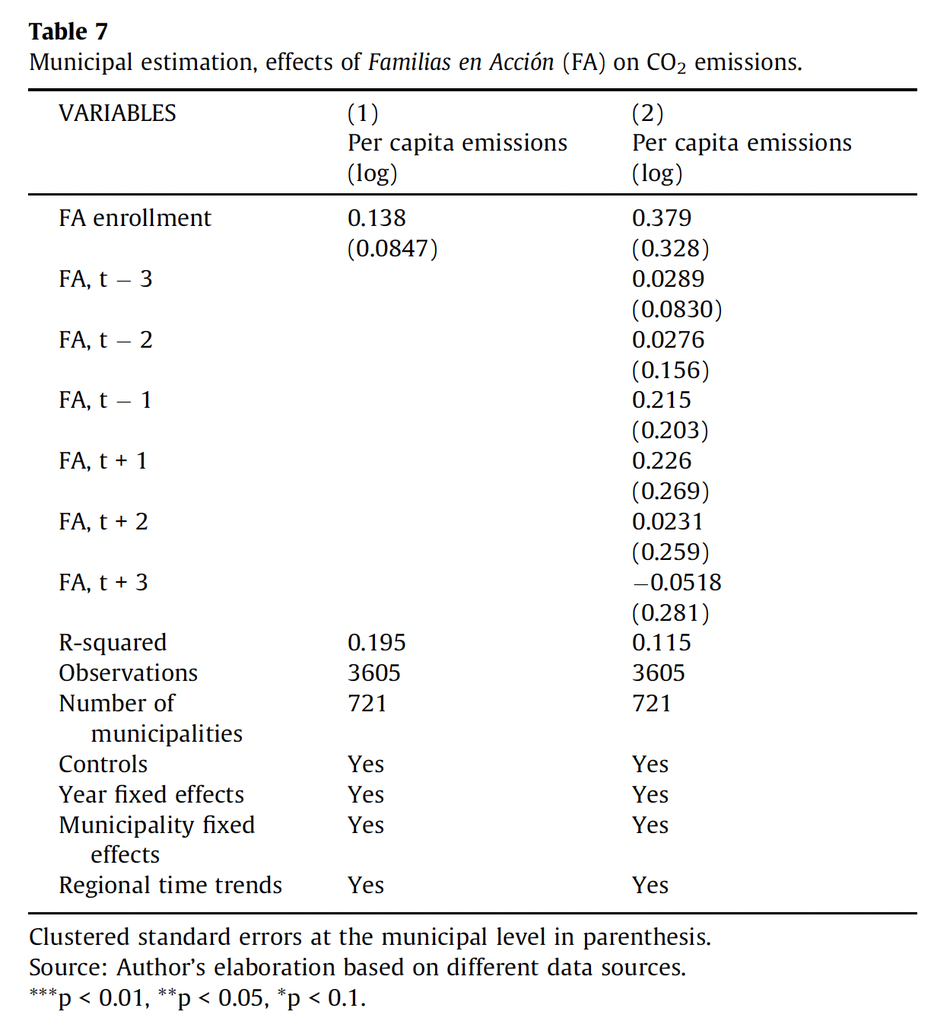

## Summary

- CCT increases the consumption of land-intensive goods and the ownership of energy-intensive assets at the household level
  - Proximity to market matters
- Participating municipalities experienced less deforestation
  - But no difference in emissions
- Policy Implications
  - Environmental impacts of poverty alleviation may be smaller than expected
  - Relationship between poverty alleviation and energy consumption is complex
  - Contextual and local factors matter